# US Open 2019 Analysis

May 17, 2019

This analysis aims to generate as comprehensive as possible summary of the event. Feel free to skip around and only view parts of the report that are interesting to you. Visualizations are presented in addtion to tables and narrations.

Please follow links to interesting matches or search for a wrestler by copying their name into our search database [here!](http://www.veritaswrestlingsystems.com/ratings/)

# Table of Contents

## Individual Analysis

Top

Top/bottom performances are mostly ranked on Action per Minute (APM), Neutral Pace Factor(NPF), and Results. Emphasis is placed on these metrics because APM and NPF have been shown to be highly correlated with long-term success (*r=0.92, r=0.88* respectively). The following section focuses on wrestlers' performances across the entire tournament and requires three or more matches to be included. Top performances for individual matches can be found further below.

### Top Perfomers

Top performers for this event are (in order):

1. [Justin Deangelis](http://www.veritaswrestlingsystems.com/wrestlers/justin-deangelis/) -- 70kgs
2. [Lavion Mayes](http://www.veritaswrestlingsystems.com/wrestlers/lavion-mayes/) -- 70kgs
3. [Yianni Diakomihalis](http://www.veritaswrestlingsystems.com/wrestlers/yianni-diakomihalis/) -- 65kgs

Key perfomance metrics between all wrestlers and the top performers:

|  | All | Top |
| --- | --- | --- |
| APM | 11.86 | 22.27 |
| NPF | 1.04 | 1.30 |
| NumResult | 0.95 | 1.18 |

| Focus | APM | NPF | NumResult | Duration | PassiveDiff | FocusPoints | OppPoints | MoV |
| --- | --- | --- | --- | --- | --- | --- | --- | --- |
| Justin Deangelis | 23.0 | 1.30 | 1.18 | 269.05 | -0.60 | 10.00 | 5.8 | 4.20 |
| Lavion Mayes | 23.0 | 1.13 | 1.10 | 290.54 | 0.25 | 10.75 | 8.5 | 2.25 |
| Yianni Diakomihalis | 20.8 | 1.46 | 1.26 | 337.18 | -0.60 | 9.80 | 3.2 | 6.60 |

### Bottom Performers

Key perfomance metrics between ALL wrestlers and the Bottom Performers:

|  | All | Bottom |
| --- | --- | --- |
| APM | 11.86 | 4.00 |
| NPF | 1.04 | 0.75 |
| NumResult | 0.95 | 0.56 |

| Focus | APM | NPF | NumResult | Duration | PassiveDiff | FocusPoints | OppPoints | MoV |
| --- | --- | --- | --- | --- | --- | --- | --- | --- |
| Patrick Romero | 3.33 | 0.92 | 0.58 | 113.08 | -0.67 | 1.00 | 7.67 | -6.67 |
| Kyle Kintz | 4.00 | 0.50 | 0.58 | 84.23 | 0.00 | 2.00 | 7.33 | -5.33 |
| Phil Rasmussen | 4.67 | 0.83 | 0.50 | 80.57 | -0.67 | 3.33 | 6.67 | -3.33 |

### Top Individual Match Performance

This section focuses on individual matches for all wrestlers who competed in the event.  
Analysis will still favor the KPMs (Key Performance Metrics: APM and NPF).

11 matches with a WinF result and 2.0 NPF.

|  | Result | MatchID | Focus | Opponent | NPF | APM | Duration | FocusPoints | OppPoints |
| --- | --- | --- | --- | --- | --- | --- | --- | --- | --- |
| 843 | WinF | HTMU* | Elroy Perkin | Joshua Kindig | 2.0 | 12.0 | 95.74 | 8 | 0 |
| 669 | WinF | DXNJ* | Conrad Cole | Ernesto Garcia | 2.0 | 11.0 | 54.80 | 8 | 0 |
| 1598 | WinF | PPH7* | Michael Macchiavello | Timothy Dudley | 2.0 | 10.0 | 263.87 | 9 | 0 |
| 763 | WinF | V8TQ | Joshua Asper | David Richardson | 2.0 | 9.0 | 36.90 | 8 | 0 |
| 1400 | WinF | SY70 | Matthew Malcom | Austin Farbaugh | 2.0 | 8.0 | 67.43 | 6 | 0 |
| 544 | WinF | U72K* | Cameron Caffey | Jake Posey | 2.0 | 7.0 | 88.74 | 4 | 0 |
| 955 | WinF | QW3W | Geno Morelli | Kyle Matthews | 2.0 | 6.0 | 17.42 | 4 | 0 |
| 524 | WinF | DQW8* | Nikko Reyes | Nicholas Nottingham | 2.0 | 5.0 | 30.53 | 4 | 0 |
| 652 | WinF | KYO5 | Nathan Jackson | Ethan Vistro | 2.0 | 5.0 | 12.70 | 4 | 0 |
| 997 | WinF | M8Q4* | Noel Orozco | Kyle La Fritz | 2.0 | 5.0 | 18.71 | 4 | 0 |
| 1165 | WinF | 5N6D* | Jarrod Hinrichs | Kyle Jennings | 2.0 | 5.0 | 21.41 | 4 | 0 |

From this list of matches it is clear that there are many great performances to choose from. The Perkin WinF over Kindig is tempting as it has the highest APM of any match with a 2.0 NPF and WinF result. However, the Cole WinF over Garcia seems a stronger contender as it has roughly the same APM and was finished in half the time (55 seconds versus 96 seconds).

> Ultimately I will drop both of these options in favor of the 40.0 APM Graff WinD over Brewer. This match was a 38 point storm that resulted in the highest APM of the tournament despite a relateively even NPF (1.15 for Graff).

## Weight Class Analysis

### 57 kilos

Top

#### Placements

1. [Daton Fix](http://www.veritaswrestlingsystems.com/wrestlers/daton-fix/)
2. [Thomas Gilman](http://www.veritaswrestlingsystems.com/wrestlers/thomas-gilman/)
3. [Zane Richards](http://www.veritaswrestlingsystems.com/wrestlers/zane-richards/)
4. [Vitali Arujau](http://www.veritaswrestlingsystems.com/wrestlers/vitali-arujau/)

#### Distributions

This section focuses on illustrating the distribution of Results and ShotTypes for this event.1

Tech-falls are the more common as is typical with a Freestyle event.

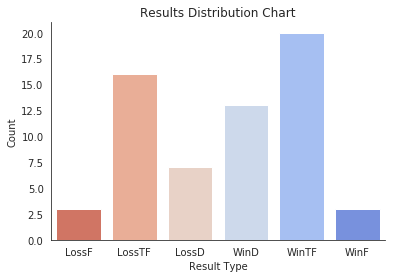

GBa will almost exclusively be #1 on this list due to the large variety of conditions under which it is recorded.

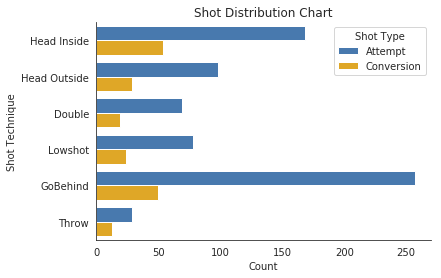

#### Trends

This section focuses on identifying key metrics for success at this weight (at this event).

The analysis does not take into consideration the value of more powerful results. In otherwords, correlations are done only on win/loss results and **not** on the degree of the result (i.e. tech-fall versus pin). So a strong correlation indicates a higher relationship with winning but **not** the degree of winning.

Remember correlations range from -1 to +1 the former representating a strong relationship with a negative outcome (in this case losing the match) and the latter representation a strong relationship with a positive outcome (i.e. winning a match). Correlations closer to 0 represent weak relationships and correlations around 0.5 represent moderate relationships.

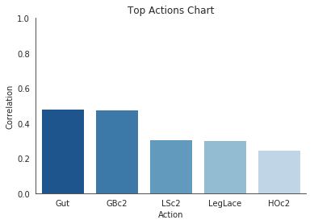

### 61 kilos

Top

#### Placements

1. [Cody Brewer](http://www.veritaswrestlingsystems.com/wrestlers/cody-brewer/)
2. [Nico Megaludis](http://www.veritaswrestlingsystems.com/wrestlers/nico-megaludis/)
3. [Joey Palmer](http://www.veritaswrestlingsystems.com/wrestlers/joey-palmer/)
4. [Tyler Graff](http://www.veritaswrestlingsystems.com/wrestlers/tyler-graff/)

#### Distributions

This section focuses on illustrating the distribution of Results and ShotTypes for this event.

Tech-falls are the more common as is typical with a Freestyle event.

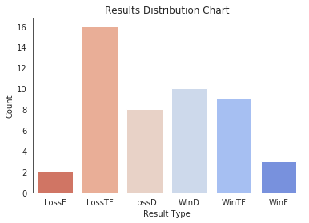

GBa will almost exclusively be #1 on this list due to the large variety of conditions under which it is recorded.

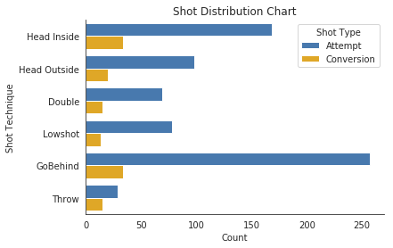

#### Trends

This section focuses on identifying key metrics for success at this weight (at this event).

The analysis does not take into consideration the value of more powerful results. In otherwords, correlations are done only on win/loss results and not on the degree of the result (i.e. tech-fall versus pin). So a strong correlation indicates a higher relationship with winning but not the degree of winning.

Remember correlations range from -1 to +1 the former representating a strong relationship with a negative outcome (in this case losing the match) and the latter representation a strong relationship with a positive outcome (i.e. winning a match). Correlations closer to 0 represent weak relationships and correlations around 0.5 represent moderate relationships.

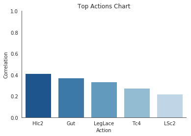

### 65 kilos

Top

#### Placements

1. [Yianni Diakomihalis](http://www.veritaswrestlingsystems.com/wrestlers/yianni-diakomihalis/)
2. [Zain Retherford](http://www.veritaswrestlingsystems.com/wrestlers/zain-retherford/)
3. [Jason Ness](http://www.veritaswrestlingsystems.com/wrestlers/jason-ness/)
4. [Frank Molinaro](http://www.veritaswrestlingsystems.com/wrestlers/frank-molinaro/)

#### Distributions

This section focuses on illustrating the distribution of Results and ShotTypes for this event.

Tech-falls are the more common as is typical with a Freestyle event.

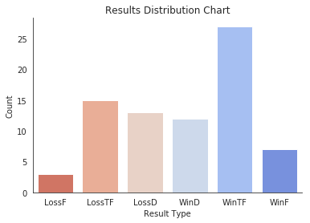

GBa will almost exclusively be #1 on this list due to the large variety of conditions under which it is recorded.

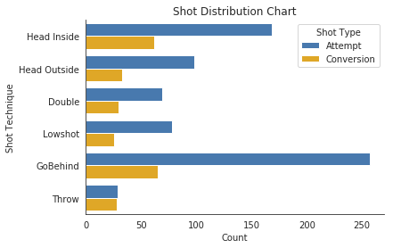

#### Trends

This section focuses on identifying key metrics for success at this weight (at this event).

The analysis does not take into consideration the value of more powerful results. In otherwords, correlations are done only on win/loss results and not on the degree of the result (i.e. tech-fall versus pin). So a strong correlation indicates a higher relationship with winning but not the degree of winning.

Remember correlations range from -1 to +1 the former representating a strong relationship with a negative outcome (in this case losing the match) and the latter representation a strong relationship with a positive outcome (i.e. winning a match). Correlations closer to 0 represent weak relationships and correlations around 0.5 represent moderate relationships.

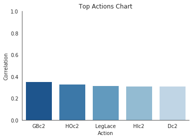

### 70 kilos

Top

#### Placements

1. [Ryan Deakin](http://www.veritaswrestlingsystems.com/wrestlers/ryan-deakin/)
2. [James Green](http://www.veritaswrestlingsystems.com/wrestlers/james-green/)
3. [Jason Nolf](http://www.veritaswrestlingsystems.com/wrestlers/jason-nolf/)
4. [Alec Pantaleo](http://www.veritaswrestlingsystems.com/wrestlers/alec-pantaleo/)

#### Distributions

This section focuses on illustrating the distribution of Results and ShotTypes for this event.

Tech-falls are the more common as is typical with a Freestyle event.

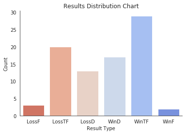

GBa will almost exclusively be #1 on this list due to the large variety of conditions under which it is recorded.

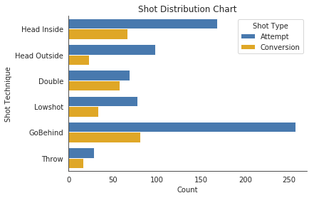

#### Trends

This section focuses on identifying key metrics for success at this weight (at this event).

The analysis does not take into consideration the value of more powerful results. In otherwords, correlations are done only on win/loss results and not on the degree of the result (i.e. tech-fall versus pin). So a strong correlation indicates a higher relationship with winning but not the degree of winning.

Remember correlations range from -1 to +1 the former representating a strong relationship with a negative outcome (in this case losing the match) and the latter representation a strong relationship with a positive outcome (i.e. winning a match). Correlations closer to 0 represent weak relationships and correlations around 0.5 represent moderate relationships.

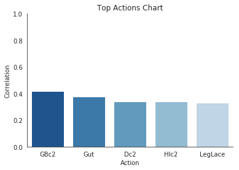

### 74 kilos

Top

#### Placements

1. [Isaiah Martinez](http://www.veritaswrestlingsystems.com/wrestlers/isaiah-martinez/)
2. [Thomas Gantt](http://www.veritaswrestlingsystems.com/wrestlers/thomas-gantt/)
3. [Anthony Valencia](http://www.veritaswrestlingsystems.com/wrestlers/anthony-valencia/)
4. [Dan Vallimont](http://www.veritaswrestlingsystems.com/wrestlers/dan-vallimont/)

#### Distributions

This section focuses on illustrating the distribution of Results and ShotTypes for this event.

Tech-falls are the more common as is typical with a Freestyle event.

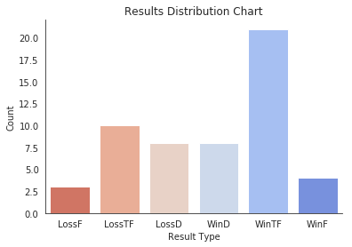

GBa will almost exclusively be #1 on this list due to the large variety of conditions under which it is recorded.

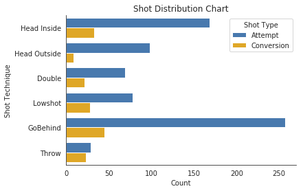

#### Trends

This section focuses on identifying key metrics for success at this weight (at this event).

The analysis does not take into consideration the value of more powerful results. In otherwords, correlations are done only on win/loss results and not on the degree of the result (i.e. tech-fall versus pin). So a strong correlation indicates a higher relationship with winning but not the degree of winning.

Remember correlations range from -1 to +1 the former representating a strong relationship with a negative outcome (in this case losing the match) and the latter representation a strong relationship with a positive outcome (i.e. winning a match). Correlations closer to 0 represent weak relationships and correlations around 0.5 represent moderate relationships.

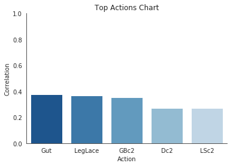

### 79 kilos

Top

#### Placements

1. [Alex Dieringer](http://www.veritaswrestlingsystems.com/wrestlers/alex-dieringer/)
2. [Chance Marsteller](http://www.veritaswrestlingsystems.com/wrestlers/chance-marsteller/)
3. [Nick Becker](http://www.veritaswrestlingsystems.com/wrestlers/nick-becker/)
4. [Matthew Finesilver](http://www.veritaswrestlingsystems.com/wrestlers/matthew-finesilver/)

#### Distributions

This section focuses on illustrating the distribution of Results and ShotTypes for this event.

Tech-falls are the more common as is typical with a Freestyle event.

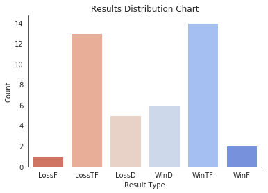

GBa will almost exclusively be #1 on this list due to the large variety of conditions under which it is recorded.

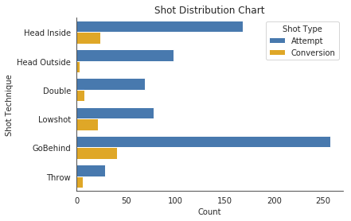

#### Trends

This section focuses on identifying key metrics for success at this weight (at this event).

The analysis does not take into consideration the value of more powerful results. In otherwords, correlations are done only on win/loss results and not on the degree of the result (i.e. tech-fall versus pin). So a strong correlation indicates a higher relationship with winning but not the degree of winning.

Remember correlations range from -1 to +1 the former representating a strong relationship with a negative outcome (in this case losing the match) and the latter representation a strong relationship with a positive outcome (i.e. winning a match). Correlations closer to 0 represent weak relationships and correlations around 0.5 represent moderate relationships.

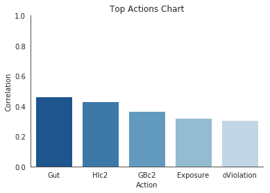

### 86 kilos

Top

#### Placements

1. [Pat Downey](http://www.veritaswrestlingsystems.com/wrestlers/pat-downey/)
2. [Nicholas Heflin](http://www.veritaswrestlingsystems.com/wrestlers/nicholas-heflin/)
3. [Samuel Brooks](http://www.veritaswrestlingsystems.com/wrestlers/samuel-brooks/)
4. [Brett Pfarr](http://www.veritaswrestlingsystems.com/wrestlers/brett-pfarr/)

#### Distributions

This section focuses on illustrating the distribution of Results and ShotTypes for this event.

Tech-falls are the more common as is typical with a Freestyle event.

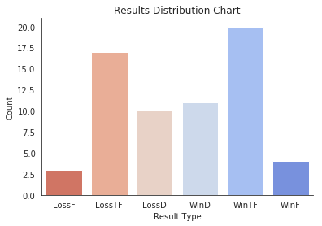

GBa will almost exclusively be #1 on this list due to the large variety of conditions under which it is recorded.

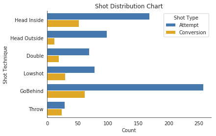

#### Trends

This section focuses on identifying key metrics for success at this weight (at this event).

The analysis does not take into consideration the value of more powerful results. In otherwords, correlations are done only on win/loss results and not on the degree of the result (i.e. tech-fall versus pin). So a strong correlation indicates a higher relationship with winning but not the degree of winning.

Remember correlations range from -1 to +1 the former representating a strong relationship with a negative outcome (in this case losing the match) and the latter representation a strong relationship with a positive outcome (i.e. winning a match). Correlations closer to 0 represent weak relationships and correlations around 0.5 represent moderate relationships.

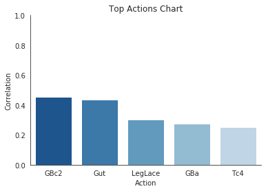

### 92 kilos

Top

#### Placements

1. [Bo Nickal](http://www.veritaswrestlingsystems.com/wrestlers/bo-nickal/)
2. [Hayden Zillmer](http://www.veritaswrestlingsystems.com/wrestlers/hayden-zillmer/)
3. [Michael Macchiavello](http://www.veritaswrestlingsystems.com/wrestlers/michael-macchiavello/)
4. [Timothy Dudley](http://www.veritaswrestlingsystems.com/wrestlers/timothy-dudley/)

#### Distributions

This section focuses on illustrating the distribution of Results and ShotTypes for this event.

Tech-falls are the more common as is typical with a Freestyle event.

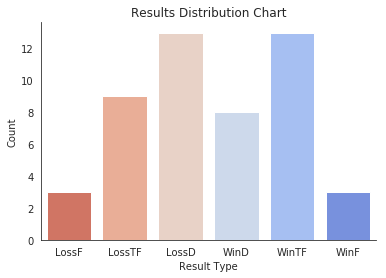

GBa will almost exclusively be #1 on this list due to the large variety of conditions under which it is recorded.

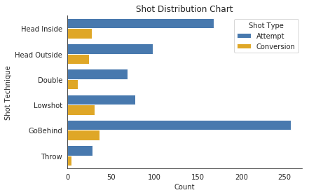

#### Trends

This section focuses on identifying key metrics for success at this weight (at this event).

The analysis does not take into consideration the value of more powerful results. In otherwords, correlations are done only on win/loss results and not on the degree of the result (i.e. tech-fall versus pin). So a strong correlation indicates a higher relationship with winning but not the degree of winning.

Remember correlations range from -1 to +1 the former representating a strong relationship with a negative outcome (in this case losing the match) and the latter representation a strong relationship with a positive outcome (i.e. winning a match). Correlations closer to 0 represent weak relationships and correlations around 0.5 represent moderate relationships.

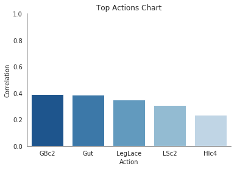

### 97 kilos

Top

#### Placements

1. [Kyven Gadson](http://www.veritaswrestlingsystems.com/wrestlers/kyven-gadson/)
2. [Benjamin Honis](http://www.veritaswrestlingsystems.com/wrestlers/ben-honis/)
3. [Danny Chaid](http://www.veritaswrestlingsystems.com/wrestlers/danny-chaid/)
4. [Ty Walz](http://www.veritaswrestlingsystems.com/wrestlers/ty-walz/)

#### Distributions

This section focuses on illustrating the distribution of Results and ShotTypes for this event.

Tech-falls are the more common as is typical with a Freestyle event.

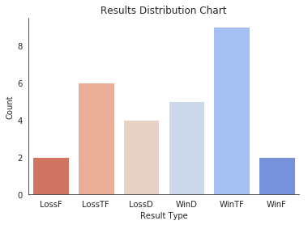

GBa will almost exclusively be #1 on this list due to the large variety of conditions under which it is recorded.

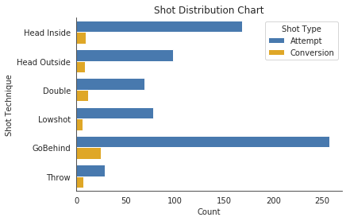

#### Trends

This section focuses on identifying key metrics for success at this weight (at this event).

The analysis does not take into consideration the value of more powerful results. In otherwords, correlations are done only on win/loss results and not on the degree of the result (i.e. tech-fall versus pin). So a strong correlation indicates a higher relationship with winning but not the degree of winning.

Remember correlations range from -1 to +1 the former representating a strong relationship with a negative outcome (in this case losing the match) and the latter representation a strong relationship with a positive outcome (i.e. winning a match). Correlations closer to 0 represent weak relationships and correlations around 0.5 represent moderate relationships.

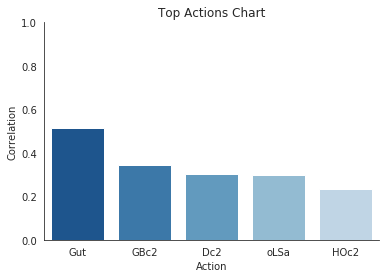

### 125 kilos

Top

#### Placements

1. [Adam Coon](http://www.veritaswrestlingsystems.com/wrestlers/adam-coon/)
2. [Anthony Nelson](http://www.veritaswrestlingsystems.com/wrestlers/anthony-nelson/)
3. [Dom Bradley](http://www.veritaswrestlingsystems.com/wrestlers/dom-bradley/)
4. [Derek White](http://www.veritaswrestlingsystems.com/wrestlers/derek-white/)

#### Distributions

This section focuses on illustrating the distribution of Results and ShotTypes for this event.

Tech-falls are the more common as is typical with a Freestyle event.

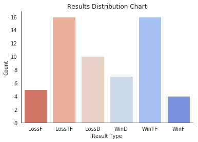

GBa will almost exclusively be #1 on this list due to the large variety of conditions under which it is recorded.

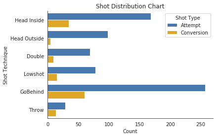

#### Trends

This section focuses on identifying key metrics for success at this weight (at this event).

The analysis does not take into consideration the value of more powerful results. In otherwords, correlations are done only on win/loss results and not on the degree of the result (i.e. tech-fall versus pin). So a strong correlation indicates a higher relationship with winning but not the degree of winning.

Remember correlations range from -1 to +1 the former representating a strong relationship with a negative outcome (in this case losing the match) and the latter representation a strong relationship with a positive outcome (i.e. winning a match). Correlations closer to 0 represent weak relationships and correlations around 0.5 represent moderate relationships.

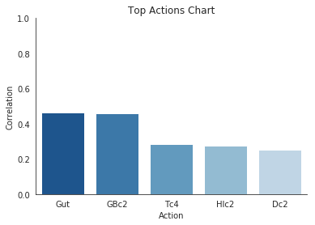

### Comparison

The comparison between weight classes will focus mostly on Shot Types and Point Distributions as opposed to the result-based distribution above.

Below is a table illustrating different Shot Type conversion rates for the various weight classes. This table can be interpreted multiple ways. For instance, is a low conversion rate due to wrestlers at that weight being incapable/inefficient at finishing, or is it a sign that opponents at that weight are excellent defenders of that shot? The following discussion attempts to take both of these perspectives into consideration.

Firstly, it is important to state that top scores for a particular column (or shot type) are highlighted in blue, while bottom scores are highlighted in gold. This table should be read across (left to right), checking the weight class and then identifying its highest/lowest values. Knowing this, we can clearly identify the best/worst weight class for any given shot type. We can see, for example, that 74kgs has the highest Throw-rate. Interestingly, 125kgs has the highest GBrate... perhaps because of their size.

Further, some athletes or coaches may find this chart interesting to compare the dynamics of different weight classes in the neutral position. However, these numbers do not represent correlations to success but only raw averages, so bear that in mind.

| Weight | HIrate | HOrate | Drate | LSrate | GBrate | Trate | AverageRate |
| --- | --- | --- | --- | --- | --- | --- | --- |
| 57 | 21.6 | 13.78 | 9.84 | 12.16 | 15.95 | 6.85 | 13.36 |
| 61 | 21.18 | 12.53 | 9.81 | 7.81 | 12 | 13.54 | 12.81 |
| 65 | 19.77 | 14.19 | 13.87 | 7.77 | 17.3 | 12.86 | 14.29 |
| 70 | 16.45 | 10.27 | 17.08 | 11.31 | 17.46 | 9.52 | 13.68 |
| 74 | 14.5 | 6.02 | 9.12 | 14.69 | 16.27 | 17.13 | 12.96 |
| 79 | 17.26 | 1.7 | 6.1 | 10.92 | 16.09 | 7.32 | 9.9 |
| 86 | 22.39 | 5.95 | 10.31 | 14.81 | 16.45 | 13.33 | 13.87 |
| 92 | 14.97 | 11.96 | 6.72 | 18.71 | 13.6 | 4.08 | 11.67 |
| 97 | 10.37 | 13.39 | 16.07 | 9.82 | 19 | 11.61 | 13.38 |
| 125 | 19.54 | 2.18 | 7.47 | 8.65 | 22.95 | 12.07 | 12.14 |

The next table illustrates the various ways to earn points in a match (with the exception of opponent violations). This table has the same highlighting as the previous one, but should be read vertically (top to bottom) first identifying the weight class of interest then locating its highest/lowest scores.

The scores in this table represent the average points earned per match by each action/technique for each weight class. Similar to the table above this table has multiple possible interpretations. For example, does an action/technique have a low value because it is executed poorly, defended well, *or* because it is rare and does not occur often?

| Weight | 57 | 61 | 65 | 70 | 74 | 79 | 86 | 92 | 97 | 125 | AvgPoints |
| --- | --- | --- | --- | --- | --- | --- | --- | --- | --- | --- | --- |
| HIc2 | 0.77 | 0.67 | 0.7 | 0.75 | 0.57 | 0.54 | 0.75 | 0.47 | 0.32 | 0.52 | 0.61 |
| HIc4 | 0.1 | 0.04 | 0.1 | 0.05 | 0.04 | 0.05 | 0.05 | 0.1 | 0.04 | 0.09 | 0.06 |
| HOc2 | 0.35 | 0.33 | 0.39 | 0.21 | 0.17 | 0.05 | 0.15 | 0.45 | 0.25 | 0.07 | 0.24 |
| HOc4 | 0.11 | 0.08 | 0.04 | 0.06 | 0 | 0.02 | 0.03 | 0.06 | 0.07 | 0.02 | 0.05 |
| Dc2 | 0.23 | 0.23 | 0.3 | 0.58 | 0.31 | 0.17 | 0.23 | 0.18 | 0.32 | 0.12 | 0.27 |
| Dc4 | 0.08 | 0.08 | 0.09 | 0.11 | 0.09 | 0.02 | 0.06 | 0.06 | 0.11 | 0.05 | 0.08 |
| LSc2 | 0.37 | 0.27 | 0.28 | 0.36 | 0.52 | 0.49 | 0.38 | 0.55 | 0.14 | 0.24 | 0.36 |
| LSc4 | 0.02 | 0.02 | 0.05 | 0.05 | 0 | 0.05 | 0.08 | 0.08 | 0.07 | 0.02 | 0.04 |
| GBc2 | 0.81 | 0.71 | 0.84 | 0.96 | 0.83 | 1 | 0.95 | 0.76 | 0.89 | 1.03 | 0.88 |
| Tc2 | 0.1 | 0.1 | 0.06 | 0.02 | 0.15 | 0.07 | 0.12 | 0.02 | 0.04 | 0.03 | 0.07 |
| Tc4 | 0.11 | 0.21 | 0.3 | 0.18 | 0.28 | 0.07 | 0.25 | 0.08 | 0.21 | 0.21 | 0.19 |
| Exposure | 0.61 | 0.75 | 0.79 | 0.42 | 0.65 | 0.88 | 0.48 | 0.47 | 0.25 | 0.21 | 0.55 |
| Gut | 0.98 | 1.1 | 0.52 | 0.63 | 0.63 | 0.83 | 0.83 | 0.76 | 1.68 | 0.97 | 0.89 |
| LegLace | 0.45 | 0.73 | 0.53 | 0.56 | 0.69 | 0.44 | 0.66 | 0.41 | 0.14 | 0.29 | 0.49 |
| Turn | 0.16 | 0.08 | 0.15 | 0.1 | 0.19 | 0.1 | 0.17 | 0.14 | 0.18 | 0.09 | 0.14 |
| Pushout | 0.35 | 0.22 | 0.26 | 0.36 | 0.42 | 0.27 | 0.42 | 0.15 | 0.2 | 0.43 | 0.31 |

## Madness Matches

This section focuses on matches with abnormal outcomes. This is sometimes statistically determined (i.e. matches with metric values outside their third standard deviation values, but sometimes can be determined visually using common sense.

### Match OEJV (Jesse Vasquez vs Brandon Wright)

[Link to Match](http://www.veritaswrestlingsystems.com/matchdata/OEJV/)

This match went the distance as Vasquez and Wright put up 35 combined points.  
A back and forth battle, the MoV never exceeded +/- 4 for either wrestler. The deciding factor came when Wright took the lead with a go-behind and 4 succesive leg laces with less than a minute to go. Vasquez managed a takedown and two gut wrenches to come within 1 point but was unable to take the lead in the last 5 seconds.

|  | APM | Drate | Da | Date | Dc2 | Dc4 | Duration | Exposure | Focus | FocusPoints | ... | Tc4 | Turn | Violation | VS | Weight | PassiveDiff | NumResult | BinaryResult | BinaryResultText | ResultType |
| --- | --- | --- | --- | --- | --- | --- | --- | --- | --- | --- | --- | --- | --- | --- | --- | --- | --- | --- | --- | --- | --- |
| 1325 | 30.0 | 100.0 | 1 | 2019-04-26 | 1 | 0 | 360.45 | 2 | Jesse Vasquez | 17 | ... | 0 | 0 | 0 | 45.9 | 65 | 0 | 0.9 | 0 | Loss | Decision |

1 rows × 85 columns

## Veritas Bites

This section emphasizes Veritas Score which accounts for the match result, NPF, and APM and puts all of these KPMs plus over 70 other data points from each match to into a formula that outputs a numeric representation of overall match performance. Veritas Score scales based on the degree of victory.

### Overall Event

|  | count | mean | std | min | 25% | 50% | 75% | max |
| --- | --- | --- | --- | --- | --- | --- | --- | --- |
| VS | 1133.0 | 18.42 | 15.13 | -13.0 | 5.11 | 16.12 | 31.98 | 63.5 |

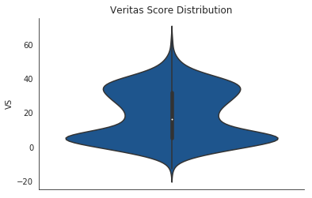

### High Value

Match X4HH had the highest VS (63.5) in a Jason Ness WinTF over Dom Demas.

|  | APM | Drate | Da | Date | Dc2 | Dc4 | Duration | Exposure | Focus | FocusPoints | ... | Tc4 | Turn | Violation | VS | Weight | PassiveDiff | NumResult | BinaryResult | BinaryResultText | ResultType |
| --- | --- | --- | --- | --- | --- | --- | --- | --- | --- | --- | --- | --- | --- | --- | --- | --- | --- | --- | --- | --- | --- |
| 1431 | 28.0 | 0.0 | 1 | 2019-04-26 | 0 | 0 | 264.58 | 0 | Jason Ness | 15 | ... | 2 | 0 | 0 | 63.5 | 65 | 0 | 1.5 | 1 | Win | Tech |

1 rows × 85 columns

### Low Value

Match 9AOY* had the lowest VS (-13) in a LossTF Donald Mcneil fell to Wynn Michalak.

|  | APM | Drate | Da | Date | Dc2 | Dc4 | Duration | Exposure | Focus | FocusPoints | ... | Tc4 | Turn | Violation | VS | Weight | PassiveDiff | NumResult | BinaryResult | BinaryResultText | ResultType |
| --- | --- | --- | --- | --- | --- | --- | --- | --- | --- | --- | --- | --- | --- | --- | --- | --- | --- | --- | --- | --- | --- |
| 634 | 6.0 | 0.0 | 0 | 2019-04-26 | 0 | 0 | 89.02 | 0 | Donald Mcneil | 4 | ... | 0 | 0 | 0 | -13.0 | 97 | 0 | 0.0 | 0 | Loss | Tech |

1 rows × 85 columns

Prepared, analyzed, and edited by Nicholas Anthony.